# Global Insights on Iodized Salt Consumption

Author

Rahul Chowdhary DCU Id -11792

# About This Report

Iodized salt consumption is a simple yet powerful proxy for understanding global public health efforts, particularly in preventing iodine deficiency disorders.

# Introduction

Iodine is a crucial micronutrient necessary for thyroid health, brain development, and growth.  
Universal salt iodization is one of the most successful public health initiatives globally.  
This report explores trends in iodized salt consumption based on UNICEF datasets through a series of visual analyses.

# Iodized Salt Consumption Across Countries

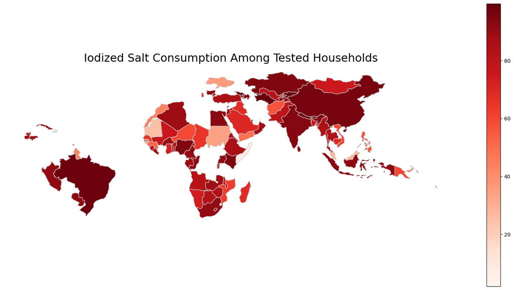

**Insight:**  
The choropleth map shows strong iodization coverage in Asia and Latin America, while Sub-Saharan Africa and parts of the Middle East lag behind.  
Concentrated initiatives are needed to extend iodine fortification efforts to these underserved regions.

# Recommended Daily Iodine Intake by Age Group

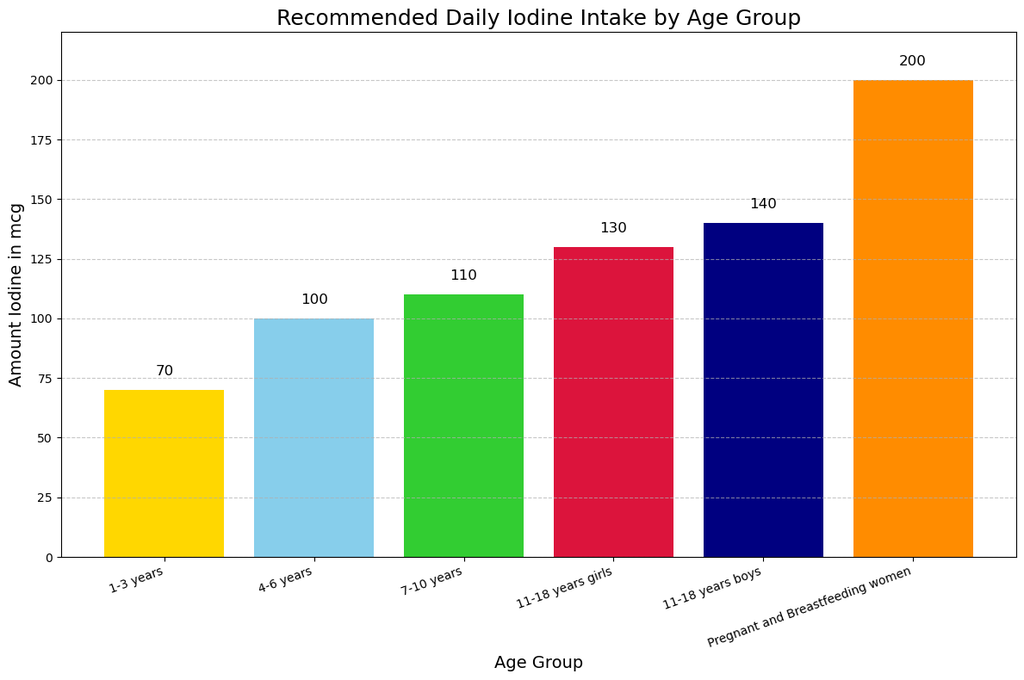

**Insight:**  
Iodine requirements vary significantly across life stages. Nutritional programs must prioritize adolescents and pregnant women, who have substantially higher iodine needs.

# Global Average Iodized Salt Consumption (2000–2020)

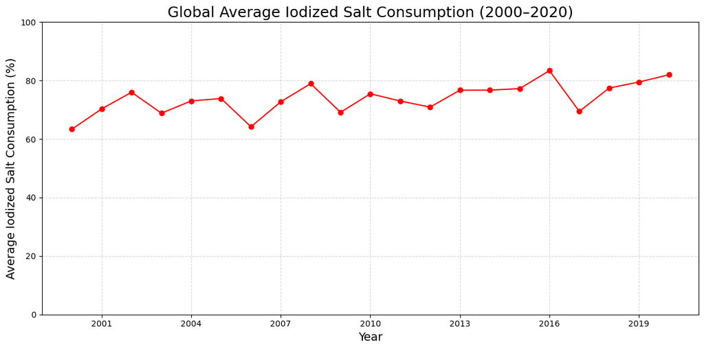

# Trend of Iodized Salt Consumption Over Time

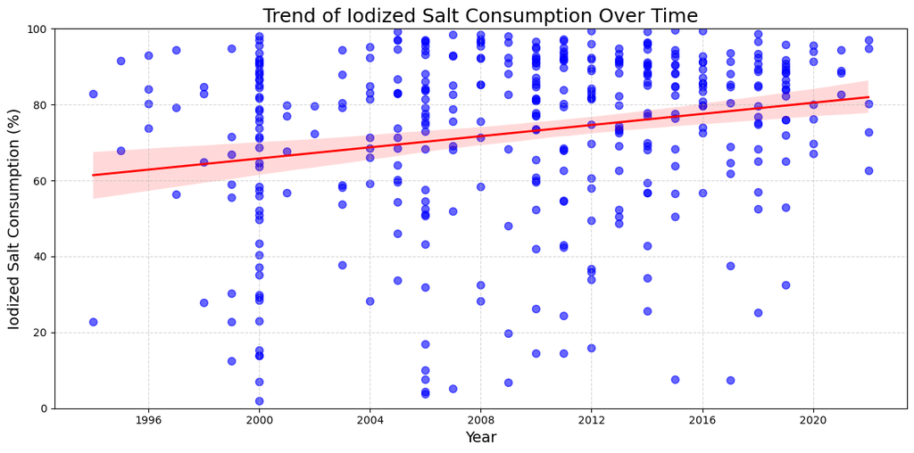

**Insight:**  
The scatter plot with a regression line indicates a positive overall trend in iodized salt consumption over time.  
However, variability among individual countries suggests that targeted interventions remain critical.

# Conclusion

Iodized salt consumption has improved significantly at the global level, preventing millions of cases of iodine deficiency-related disorders.  
Nonetheless, to completely eliminate iodine deficiency disorders (IDDs), continuous and targeted efforts are essential — especially in vulnerable countries where iodization coverage remains insufficient.